# Project1

```r
library(tm)
library(tidytext)
library(tidyverse)
library(DT)
library(tidyverse)
library(tidytext)
library(DT)
library(scales)
library(wordcloud2)
library(gridExtra)
library(ngram)
library(shiny)
library(wordcloud)
library(knitr)
library(easyGgplot2)
```

### Is Technology Making Millennials More Happy Than Human Interation?

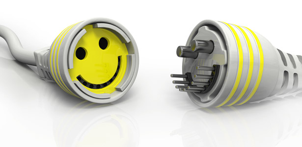

About a year ago Forbes Magazine published an article titled “Why Millennials are Lonely”. It claimed that “The second reason for millennial loneliness is the Internet makes it viral” effect. It emphasizes that “It’s not a coincidence that loneliness began to surge two years after Apple launched its first commercial personal computer and five years before Tim Berners-Lee invented the World Wide Web.” This is a narrative that is seen across major media organizations like New York Times and NPR. These mediums often use representations of millennials as people always on their phone with no touch with the outside world. It is also commonly believed that, millennials don’t want relationships as pointed out by the Huffington Post, almost pointing at a lack of need of human touch by millennials.

[figure not shown]

But are millenials as lonely as they claim? Is technology the main cause this loneliness? Are millennials not attracted to human touch anymore? Are they any different from previous and following generations. Let’s find out.

I looked through a database (happyDB) to identify what made people happy. I then selected a group of millennials(generation y), generation x and generation z as defined by the Pew Research Center. Genertion x as people between the ages of 38 and 53. Generation y as people between the ages of 22 and 37. And generation Z as people between the age of 1 and 21.

```r
# Step 1 - Load the processed text data along with demographic information on contributors

# We use the processed data for our analysis and combine it with the demographic information available.
hm_data1 <- read_csv("../output/processed_moments.csv")
hm_data2 <- read_csv("../output/processed_moments.csv")
urlfile<-'https://raw.githubusercontent.com/rit-public/HappyDB/master/happydb/data/demographic.csv'
demo_data1 <- read_csv(urlfile)
demo_data2 <- read_csv(urlfile)
#print(hm_data)
```

```r
hm_data2 <- hm_data2 %>%
  inner_join(demo_data2, by = "wid") %>%
  select(wid,
         original_hm,
         gender,
         marital,
         parenthood,
         reflection_period,
         age,
         country,
         ground_truth_category,
         text) %>%
  mutate(count = sapply(hm_data2$text, wordcount)) %>%
  filter(gender %in% c("m", "f")) %>%
  filter(marital %in% c("single", "married")) %>%
  filter(parenthood %in% c("n", "y")) %>%
  filter(reflection_period %in% c("24h", "3m")) %>%
  mutate(reflection_period = fct_recode(reflection_period,
                                        months_3 = "3m", hours_24 = "24h"))
#print(hm_data2)
```

```r
#Create bigrams using the text data
hm_bigrams2 <- hm_data2 %>%
  filter(count != 1) %>%
  unnest_tokens(bigram, text, token = "ngrams", n = 2)
bigram_counts2 <- hm_bigrams2 %>%
  separate(bigram, c("word1", "word2"), sep = " ") %>%
  count(word1, word2, sort = TRUE)
```

```r
#Create a data set with non-millenials
hm_data2$age <- as.numeric(as.character(hm_data2$age))
generationZ<-hm_data2 %>%
  filter(age>=1 & age<=21)
#print(generationZ)
generationY<-hm_data2 %>%
  filter(age>=22 & age<=37)
#print(generationY)
generationX<-hm_data2 %>%
  filter(age>=38 & age<=53)
#print(generationX)
# dim(generationX) 14560    11
# dim(generationY)70233    11
# dim(generationZ) 5540   11
```

```r
### Create a bag of words using the text data
bag_of_words1 <-generationX %>%
  unnest_tokens(word, text)
word_count1 <- bag_of_words1 %>%
  count(word, sort = TRUE)
bag_of_words2 <-  generationY %>%
  unnest_tokens(word, text)
word_count2 <- bag_of_words2 %>%
  count(word, sort = TRUE)
bag_of_words3 <-generationZ %>%
  unnest_tokens(word, text)
word_count3 <- bag_of_words3 %>%
  count(word, sort = TRUE)
```

## Genration X

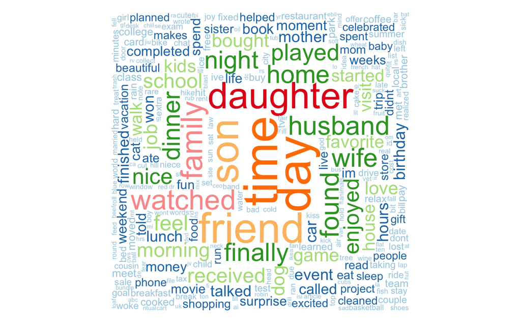

```r
set.seed(1234)
wordcloud(words = word_count1$word, freq = word_count1$n, min.freq = 1,
          max.words=10000, random.order=FALSE, rot.per=0.35,
          colors=brewer.pal(8, "Paired"), main="Generation X")
```

For generation X, we seee that there is an emphasis on time and day. This can be due to the period they are in their lives. They are older people, perhaps with different priorities which gives them a new perspective on time and how to spend it. We can also see that a many of the things that generated happiness were family members like daughter, son, husband, wife, etc. ## Genration Y##

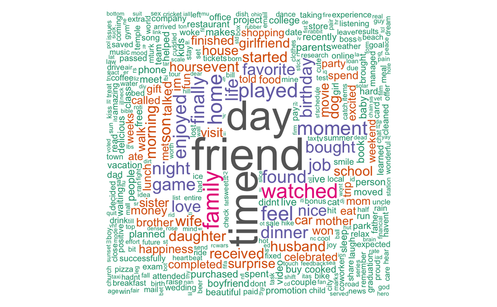

```r
set.seed(1234)
wordcloud(words = word_count2$word, freq = word_count2$n, min.freq = 1,
          max.words=10000, random.order=FALSE, rot.per=0.35,
          colors=brewer.pal(8, "Dark2"), main="Generation Y")
```

For generation Y, aka the millenials,we can see that there is a commonality in the things that bring them happines. Friends, day , and time seem to be the predominant sources of happiness. There is more in common in the sources of happiness between older and younger generations that is led on by current media. If we break it up a little more by looking at married and single millenials.

[figure not shown]

```r
par(mfrow=c(2,1))
#names(hm_data2)
singles<-hm_data2 %>%
  select(wid, original_hm, gender, marital, parenthood, reflection_period, age, country, ground_truth_category, text, count) %>%
  filter(marital == "single")
bag_of_words_s <-singles %>%
  unnest_tokens(word, text)
word_count_s <- bag_of_words_s %>%
  count(word, sort = TRUE)
mod_word_count_s<-head(word_count_s, n=10)
ggplot2.barplot(data=mod_word_count_s, xName="word",yName='n',xtickLabelRotation=90,backgroundColor="green", fill='green',color="blue", ytitle="Frequency", xtitle="Words", mainTitle="What Makes Single Millenials Happy")
```

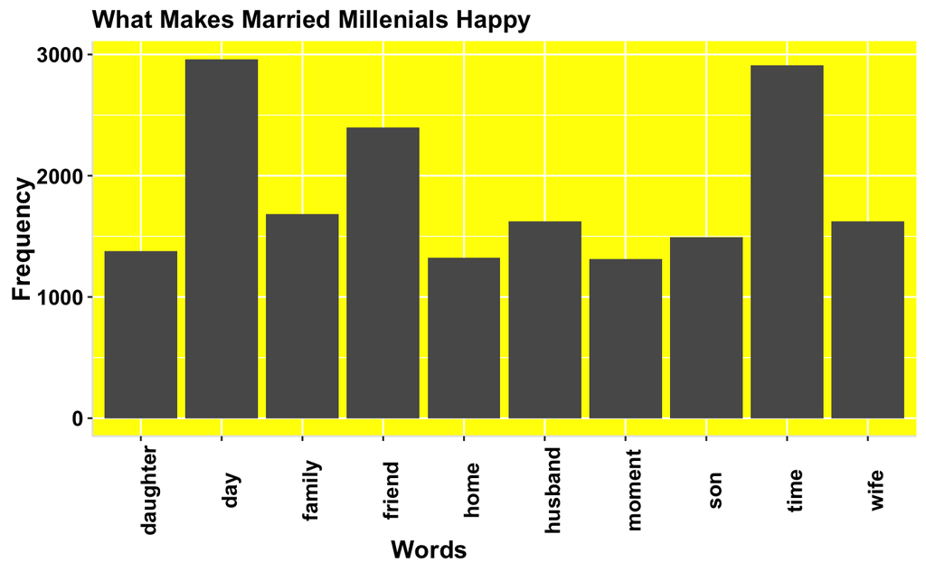

```r
married<-hm_data2 %>%
  select(wid, original_hm, gender, marital, parenthood, reflection_period, age, country, ground_truth_category, text, count) %>%
  filter(marital == "married" & age<37 & age>21)
bag_of_words_m <-married %>%
  unnest_tokens(word, text)
word_count_m <- bag_of_words_m %>%
  count(word, sort = TRUE)
mod_word_count_m<-head(word_count_m, n=10)
ggplot2.barplot(data=mod_word_count_m, xName="word",yName='n',xtickLabelRotation=90,backgroundColor="yellow", fill='yellow',color="blue", ytitle="Frequency", xtitle="Words", mainTitle="What Makes Married Millenials Happy")
```

When we look at older millenials( married ones), we can see that family aspect surging on, signaling to the differences being rooted in on the stages of their lives that the person is at not necessarily a generational issue. The married millenials graphs shows us that 50% of the top ten words are related to family something that is also present in the generation X graphs. It does not look like technology has influenced whether this happens or not, but rather perhaps, how sooner or later it happens. ## Genration Z##

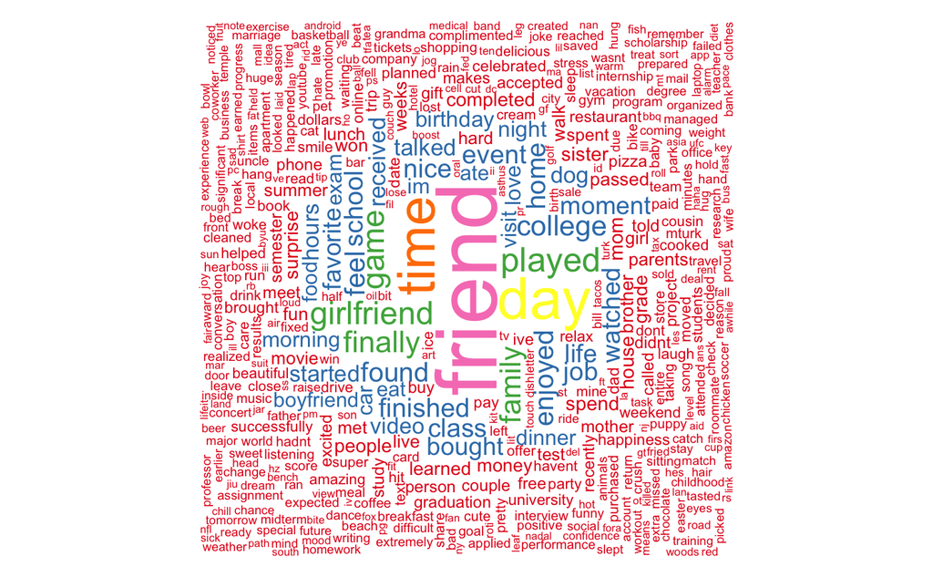

```r
set.seed(1234)
wordcloud(words = word_count3$word, freq = word_count3$n, min.freq = 1,
          max.words=10000, random.order=FALSE, rot.per=0.35,
          colors=brewer.pal(8, "Set1") ,main="Generation Z")
```

For generation Z, the word cloud shows that the most common source of happiness on those 24hours were their friends. 15 % of generation Z included friends as their top reason for their happiness. This leads to shy away from these perception of loneliness in later generations.

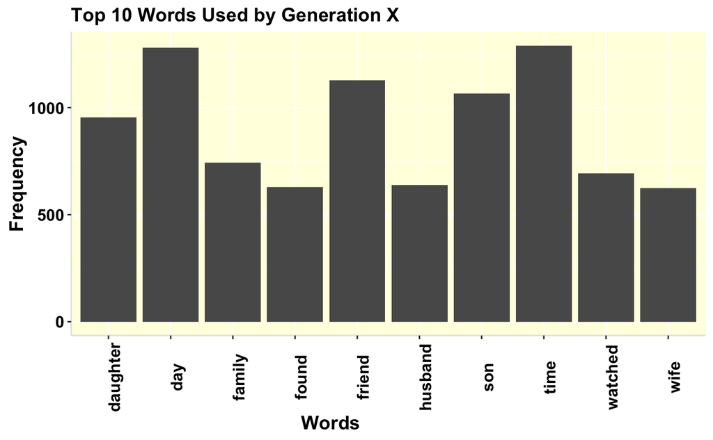

```r
# install.packages("devtools")
library(devtools)
mod_word_count1<-head(word_count1, n=10)
mod_word_count2<-head(word_count2, n=10)
mod_word_count3<-head(word_count3, n=10)
 #print(mod_word_count)
# barplot(mod_word_count)
library(easyGgplot2)
ggplot2.barplot(data=mod_word_count1, xName="word",yName='n',xtickLabelRotation=90,backgroundColor="lightyellow", fill='green',color="blue", ytitle="Frequency", xtitle="Words", mainTitle="Top 10 Words Used by Generation X")
```

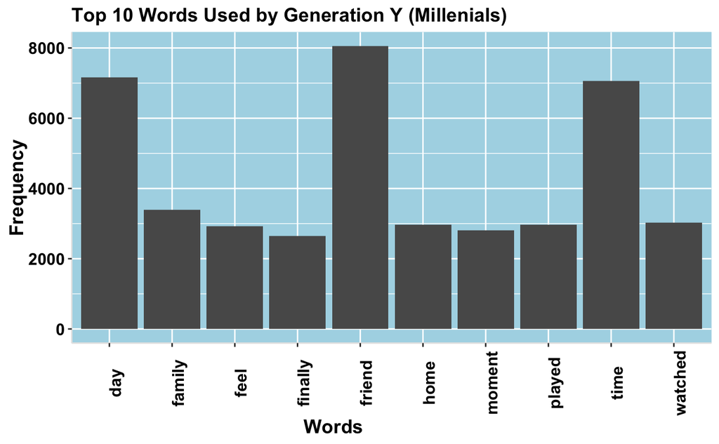

```r
ggplot2.barplot(data=mod_word_count2, xName="word",yName='n',xtickLabelRotation=90,backgroundColor="lightblue", fill='green',color="blue", ytitle="Frequency", xtitle="Words", mainTitle="Top 10 Words Used by Generation Y (Millenials)")
```

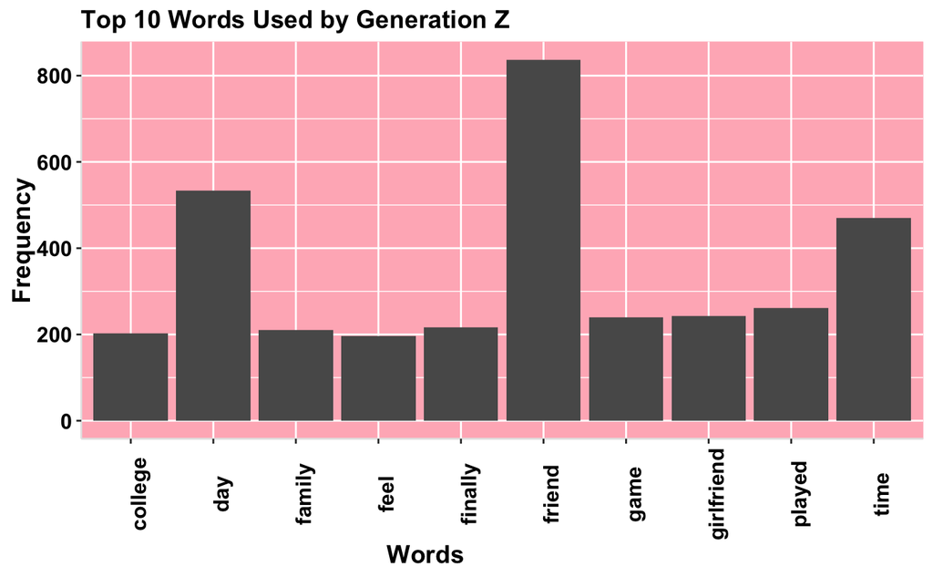

```r
ggplot2.barplot(data=mod_word_count3, xName="word",yName='n',xtickLabelRotation=90,backgroundColor="lightpink", fill='green',color="blue", ytitle="Frequency", xtitle="Words", mainTitle="Top 10 Words Used by Generation Z")
```

The most commonly used word by millenials and generation Z is friend indicating that there still a predominant human interaction. It only differs by stage of life a person finds themselves in. The data does not show that love for technology is shying away younger generations from finding happiness in the people that surround them. This just means that there are new methods and avenues to reaching that happiness.

```r
# library(easyGgplot2)
# ggplot2.barplot(data=mod_word_count1, xName="word",yName='(n/14560)*100',xtickLabelRotation=90,backgroundColor="lightyellow", fill='green',color="blue", ytitle="Percentage", xtitle="Words", mainTitle="Top 10 Words Used by Generation X")
#
# ggplot2.barplot(data=mod_word_count2, xName="word",yName='(n/70233)*100',xtickLabelRotation=90,backgroundColor="lightblue", fill='green',color="blue", ytitle="Percentage", xtitle="Words", mainTitle="Top 10 Words Used by Generation Y (Millenials)")
#
# ggplot2.barplot(data=mod_word_count3, xName="word",yName='(n/5540)*100',xtickLabelRotation=90,backgroundColor="lightpink", fill='green',color="blue", ytitle="Percentage", xtitle="Words", mainTitle="Top 10 Words Used by Generation Z")
```